# Practical Machine Learning Course Project

Anastasiia

15 november 2015

### Background

Using devices such as Jawbone Up, Nike FuelBand, and Fitbit it is now possible to collect a large amount of data about personal activity relatively inexpensively. These type of devices are part of the quantified self movement ??? a group of enthusiasts who take measurements about themselves regularly to improve their health, to find patterns in their behavior, or because they are tech geeks. One thing that people regularly do is quantify how much of a particular activity they do, but they rarely quantify how well they do it. In this project, your goal will be to use data from accelerometers on the belt, forearm, arm, and dumbell of 6 participants. They were asked to perform barbell lifts correctly and incorrectly in 5 different ways. More information is available from the website here: http://groupware.les.inf.puc-rio.br/har (see the section on the Weight Lifting Exercise Dataset).

### Data

The training data for this project are available here: https://d396qusza40orc.cloudfront.net/predmachlearn/pml-training.csv

The test data are available here: https://d396qusza40orc.cloudfront.net/predmachlearn/pml-testing.csv

### Objective

The goal of your project is to predict the manner in which they did the exercise. This is the “classe” variable in the training set. The analysis develops prediction model and uses it to predict 20 different test cases in the test data.

### Data Loading

```r
setwd("/Users/anastasia/Documents/Coursera/Practical Machine Learning")
if (!file.exists("training.csv")) {download.file("http://d396qusza40orc.cloudfront.net/predmachlearn/pml-training.csv", destfile = "training.csv")}
if (!file.exists("test.csv")) {download.file("http://d396qusza40orc.cloudfront.net/predmachlearn/pml-testing.csv", destfile = "test.csv")}
trainData<- read.csv("training.csv", na.strings = c("NA", "","#DIV/0!"))
testData<- read.csv("test.csv", na.strings = c("NA", "","#DIV/0!"))
```

### Data Processing

```r
colTr  <- colnames(trainData)
colTes <- colnames(testData)
# Verify that the column names (excluding the last columns classe and problem_id) are identical in the training and test set
print(all.equal(colTr[1:length(colTr)-1], colTes[1:length(colTes)-1]))
```

```
## [1] TRUE
```

```r
# Drop the first 7 columns as they are unnecessary for predicting
trainData<- trainData[,8:160]
testData <- testData[,8:160]
# Drop the rows if they contain more than 50% of NA values
trainData<-trainData[, colSums(is.na(trainData)) < nrow(trainData) * 0.5]
testData <-testData[, colSums(is.na(testData)) < nrow(testData) * 0.5]
```

### Data Splitting

There are 19,622 observations in the training set, so in order to reduce time and to be able to perform cross-validation, a training subset is created with 60% of the original training data set to be used for training and the remaining 40% to be used as the testing set (before final testing is performed).

```r
library(caret)
library(lattice)
library(ggplot2)
set.seed(777)
#str(trainData)
index <- createDataPartition(y=trainData$classe, p=0.6, list=FALSE)
train1 <- trainData[index, ]
test1  <- trainData[-index, ]
```

### Data fitting and predicting. Decision Tree.

```r
set.seed(777)
library(rpart)
# Grow tree
fit <- rpart(classe ~ .,method="class", data=train1)
```

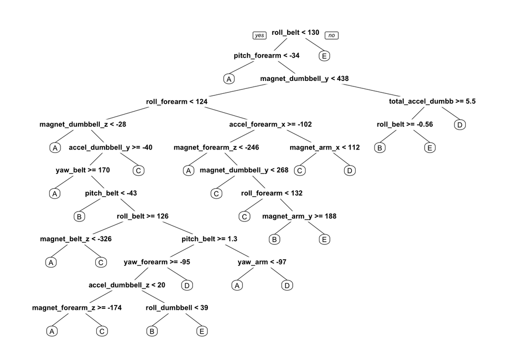

```r
#summary(fit) # detailed summary of splits
library(rpart.plot)
#plot the tree
prp(fit)
```

```r
set.seed(777)
library(caret)
c<-confusionMatrix(predict(fit,test1,type="class"), test1$classe)
# print out of sample error
print(c, digits=4)
```

```
## Confusion Matrix and Statistics
##
##           Reference
## Prediction    A    B    C    D    E
##          A 2076  325   23  126   50
##          B   51  816  118   54  115
##          C   54  231 1107  111  119
##          D   37   94  100  908  114
##          E   14   52   20   87 1044
##
## Overall Statistics
##
##                Accuracy : 0.7585
##                  95% CI : (0.7488, 0.7679)
##     No Information Rate : 0.2845
##     P-Value [Acc > NIR] : < 2.2e-16
##
##                   Kappa : 0.6929
##  Mcnemar's Test P-Value : < 2.2e-16
##
## Statistics by Class:
##
##                      Class: A Class: B Class: C Class: D Class: E
## Sensitivity            0.9301   0.5375   0.8092   0.7061   0.7240
## Specificity            0.9067   0.9466   0.9205   0.9474   0.9730
## Pos Pred Value         0.7985   0.7071   0.6825   0.7247   0.8578
## Neg Pred Value         0.9703   0.8951   0.9581   0.9427   0.9400
## Prevalence             0.2845   0.1935   0.1744   0.1639   0.1838
## Detection Rate         0.2646   0.1040   0.1411   0.1157   0.1331
## Detection Prevalence   0.3314   0.1471   0.2067   0.1597   0.1551
## Balanced Accuracy      0.9184   0.7421   0.8649   0.8267   0.8485
```

```r
print(1-c[["overall"]][["Accuracy"]])
```

```
## [1] 0.2415243
```

### Data fitting and predicting. Random Forest.

```r
set.seed(777)
library(randomForest)
library(doParallel)
library(doMC)
registerDoMC(cores = 2)
# use parallel calculation for random forest fitting
train_control <- trainControl(method="cv", number=3)
model <- train(classe~., data=train1, method="rf", trControl = train_control)
print(model)
```

```
## Random Forest
##
## 11776 samples
##    52 predictor
##     5 classes: 'A', 'B', 'C', 'D', 'E'
##
## No pre-processing
## Resampling: Cross-Validated (3 fold)
##
## Summary of sample sizes: 7850, 7851, 7851
##
## Resampling results across tuning parameters:
##
##   mtry  Accuracy   Kappa      Accuracy SD  Kappa SD
##    2    0.9858185  0.9820574  0.001879239  0.002377760
##   27    0.9862431  0.9825962  0.001420217  0.001798586
##   52    0.9814876  0.9765809  0.001947762  0.002469120
##
## Accuracy was used to select the optimal model using  the largest value.
## The final value used for the model was mtry = 27.
```

```r
# show important features
varImp(model)
```

```
## rf variable importance
##
##   only 20 most important variables shown (out of 52)
##
##                      Overall
## roll_belt            100.000
## pitch_forearm         58.909
## yaw_belt              49.990
## magnet_dumbbell_y     42.059
## pitch_belt            41.313
## magnet_dumbbell_z     40.104
## roll_forearm          39.680
## accel_dumbbell_y      22.448
## accel_forearm_x       16.988
## roll_dumbbell         16.861
## magnet_dumbbell_x     16.219
## magnet_belt_z         15.218
## accel_dumbbell_z      13.261
## total_accel_dumbbell  12.842
## magnet_forearm_z      12.355
## accel_belt_z          12.336
## magnet_belt_y         11.714
## gyros_belt_z          10.730
## yaw_arm               10.209
## magnet_belt_x          9.634
```

```r
c<-confusionMatrix(predict(model,test1[,1:length(test1)-1],type="raw"), test1$classe)
print(c, digits=4)
```

```
## Confusion Matrix and Statistics
##
##           Reference
## Prediction    A    B    C    D    E
##          A 2225   14    0    0    1
##          B    2 1502   18    1    0
##          C    4    2 1343   19    5
##          D    1    0    7 1266    2
##          E    0    0    0    0 1434
##
## Overall Statistics
##
##                Accuracy : 0.9903
##                  95% CI : (0.9879, 0.9924)
##     No Information Rate : 0.2845
##     P-Value [Acc > NIR] : < 2.2e-16
##
##                   Kappa : 0.9877
##  Mcnemar's Test P-Value : NA
##
## Statistics by Class:
##
##                      Class: A Class: B Class: C Class: D Class: E
## Sensitivity            0.9969   0.9895   0.9817   0.9844   0.9945
## Specificity            0.9973   0.9967   0.9954   0.9985   1.0000
## Pos Pred Value         0.9933   0.9862   0.9782   0.9922   1.0000
## Neg Pred Value         0.9988   0.9975   0.9961   0.9970   0.9988
## Prevalence             0.2845   0.1935   0.1744   0.1639   0.1838
## Detection Rate         0.2836   0.1914   0.1712   0.1614   0.1828
## Detection Prevalence   0.2855   0.1941   0.1750   0.1626   0.1828
## Balanced Accuracy      0.9971   0.9931   0.9885   0.9915   0.9972
```

```r
print("Out Sample Error Rate")
```

```
## [1] "Out Sample Error Rate"
```

```r
print(1-c[["overall"]][["Accuracy"]])
```

```
## [1] 0.009686464
```

```r
print("In Sample Error Rate")
```

```
## [1] "In Sample Error Rate"
```

```r
pred3<-predict(model,train1[,1:length(train1)-1],type="raw")
c<-confusionMatrix(predict(model,train1[,1:length(train1)-1],type="raw"), train1$classe)
print(1-c[["overall"]][["Accuracy"]])
```

```
## [1] 0
```

### Evaluation

```r
predFinal <- predict(model, testData, type = "raw")
print(predFinal)
```

```
##  [1] B A B A A E D B A A B C B A E E A B B B
## Levels: A B C D E
```

### Files for submitting

```r
for (i in seq(20)){
        fileName<-paste("problem",i,".txt",sep="_")
        write.table(predFinal[i],file=fileName,quote=FALSE,row.names=FALSE,col.names=FALSE)
}
```